```python
import matplotlib.pyplot as plt
import os
import pandas as pd
import seaborn as sns
from sklearn.preprocessing import StandardScaler
from sklearn.decomposition import PCA
plt.rcParams["figure.figsize"] = (20,10)
import warnings
warnings.filterwarnings('ignore')
```

```python
%%html
<style>
div.input {
    display:none;
}
</style>
```

# Examen final

**150344** Jerónimo Aranda Barois

Veamos en la siguiente linea el tamaño de nuestra muestra:

```python
df=pd.read_csv('datos-EXAMEN-FINAL-ok.csv',na_values=[' ']).dropna()
df=df.sample(2500,random_state=150344)
df.shape
```

```
(2500, 77)
```

Es decir, nuestra base tiene 2500 observaciones de 77 columnas, ahora procedamos a hacer de esta muestra, 2 submuestras, una para los estados donde transitará el tren maya y el complemento,veamos sus tamaños y sus primeros 5 elementos.

```python
df.POBTOT=pd.to_numeric(df.POBTOT)
df.GRAPROES=pd.to_numeric(df.GRAPROES)
df['A']=df.NOM_ENT.str.contains('CHIAPAS|TABASCO|QUINTANA ROO|CAMPECHE|YUCATAN',regex=True)
dfA=df.loc[df.NOM_ENT.str.contains('CHIAPAS|TABASCO|QUINTANA ROO|CAMPECHE|YUCATAN',regex=True)]
dfB=df.loc[df.NOM_ENT.str.contains('CHIAPAS|TABASCO|QUINTANA ROO|CAMPECHE|YUCATAN',regex=True)==False]
print(dfA.shape)
dfA.head()
```

```
(222, 78)
```

|  | ENTIDAD | NOM_ENT | MUNICIPIO | NOM_MUN | PEA | PEA_M | PEA_F | POCUPADA | POCUPADA_M | POCUPADA_F | ... | VPH_AGUAFV | VPH_EXCSA | VPH_DRENAJ | VPH_NODREN | VPH_C_SERV | VPH_RADIO | VPH_TV | VPH_REFRI | CONSECUTIVO | A |
| --- | --- | --- | --- | --- | --- | --- | --- | --- | --- | --- | --- | --- | --- | --- | --- | --- | --- | --- | --- | --- | --- |
| 4338 | 4 | CAMPECHE | 4 | CHAMPOTON | 550 | 431 | 119 | 543 | 426 | 117 | ... | 125 | 316 | 89 | 276 | 59 | 109 | 307 | 243 | 4339 | True |
| 41365 | 7 | CHIAPAS | 90 | TAPACHULA | 363 | 184 | 179 | 351 | 179 | 172 | ... | 18 | 270 | 270 | 0 | 251 | 197 | 258 | 245 | 41366 | True |
| 10481 | 4 | CAMPECHE | 10 | CANDELARIA | 272 | 255 | 17 | 266 | 249 | 17 | ... | 16 | 172 | 92 | 111 | 86 | 70 | 149 | 115 | 10482 | True |
| 23990 | 31 | YUCATAN | 56 | OXKUTZCAB | 503 | 333 | 170 | 493 | 326 | 167 | ... | 0 | 338 | 332 | 10 | 332 | 229 | 321 | 286 | 23991 | True |
| 41567 | 7 | CHIAPAS | 102 | TUXTLA GUTIERREZ | 2048 | 1322 | 726 | 1997 | 1279 | 718 | ... | 31 | 1197 | 1194 | 4 | 1160 | 933 | 1173 | 1100 | 41568 | True |

5 rows × 78 columns

```python
print(dfB.shape)
dfB.head()
```

[output not shown]

|  | ENTIDAD | NOM_ENT | MUNICIPIO | NOM_MUN | PEA | PEA_M | PEA_F | POCUPADA | POCUPADA_M | POCUPADA_F | ... | VPH_AGUADV | VPH_AGUAFV | VPH_EXCSA | VPH_DRENAJ | VPH_NODREN | VPH_C_SERV | VPH_RADIO | VPH_TV | VPH_REFRI | CONSECUTIVO |
| --- | --- | --- | --- | --- | --- | --- | --- | --- | --- | --- | --- | --- | --- | --- | --- | --- | --- | --- | --- | --- | --- |
| 50569 | 9 | DISTRITO FEDER | 6 | IZTACALCO | 633 | 390 | 243 | 604 | 372 | 232 | ... | 385 | 1 | 386 | 386 | 0 | 385 | 349 | 378 | 367 | 50570 |
| 31592 | 14 | JALISCO | 18 | LA BARCA | 548 | 343 | 205 | 526 | 322 | 204 | ... | 327 | 1 | 324 | 322 | 6 | 320 | 267 | 321 | 309 | 31593 |
| 25433 | 5 | COAHUILA | 35 | TORREON | 886 | 563 | 323 | 765 | 483 | 282 | ... | 502 | 0 | 500 | 499 | 3 | 498 | 401 | 496 | 490 | 25434 |
| 8320 | 25 | SINALOA | 2 | ANGOSTURA | 57 | 52 | 5 | 56 | 51 | 5 | ... | 50 | 0 | 48 | 47 | 3 | 47 | 30 | 49 | 49 | 8321 |
| 2615 | 24 | SAN LUIS POTOS | 2 | ALAQUINES | 45 | 39 | 6 | 31 | 27 | 4 | ... | 3 | 42 | 41 | 2 | 43 | 1 | 37 | 39 | 33 | 2616 |

La división parece no corresponder al número de estados que existen en la república, talvez corresponde al número de distritos que existen, esperemos no afecten los resultados.

## Pregunta 1

Para empezar veamos como están distribuidas nuestras observaciones por estado y además a qué muestra pertenecen.

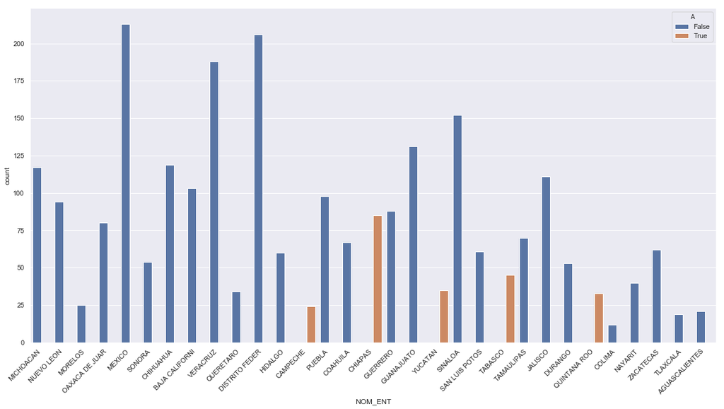

```python
ax = sns.countplot(x="NOM_ENT", hue="A", data=df)
ax=ax.set_xticklabels(ax.get_xticklabels(),rotation = 45, ha="right")
```

En general nuestra submuestra de interés A tiene menos observaciones que las de algunos otros municipios pero también más que algunos otros, esto puede ser respecto a las distritaciones del país.

A continuación veamos como es la Población éconómicamente activa respecto a la población total.

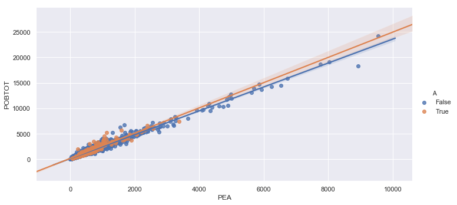

```python
ax=sns.lmplot(x='PEA',y='POBTOT',data=df,hue='A',aspect=2)
```

Aunque nuestros estados elegidos 'A' parecen estar entre el bonche, parecen tener un poco menos de población económicamente activa frente a su población total que otros estados. Para soportar esta hipótesis habría que hacer una regresión lineal y ver que las $\beta$'s sean significativas y distintas, es decir la prueba de hipótesis correspondientes.

Ahora de nuevo veamos nuestra población total frente a la población de 15 años o más que es analfabeta.

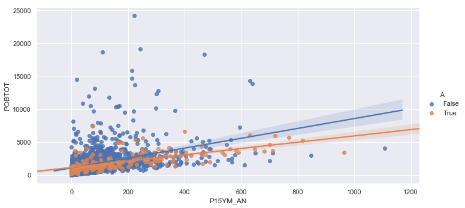

```python
sns.lmplot(x='P15YM_AN',y='POBTOT',data=df,hue='A',aspect=2)
```

En este caso parece ser inversa la relación es decir, si bien en ambos grupos hay un poco de casi todos los ratios, parece ser consistente que en nuestro grupo A, parece haber una población de 15 años más analfabeta. De nuevo habría que respaldar estas hipótesis con las correspondientes pruebas. Sin embargo, estas gráficas pueden ser suficientes pues el paquete ya ajusta los modelos lineales.

Veamos como es la población de 18 y mas frente a la población total.

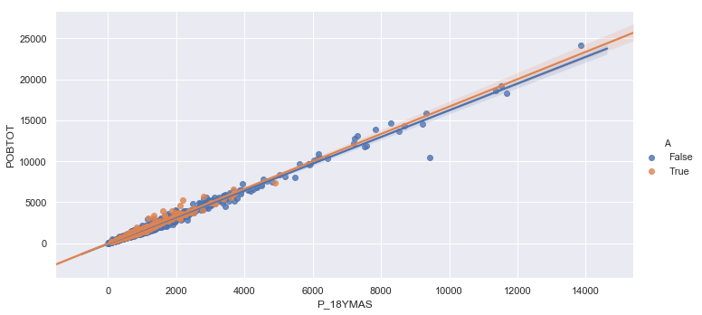

```python
sns.lmplot(x='P_18YMAS',y='POBTOT',data=df,hue='A',aspect=2)
```

Las poblaciones parecen tener casi la misma tasa $P18/{Ptot}$.

Ahora veamos viviendas viviendas con piso de tierra frente a viviendas habitadas

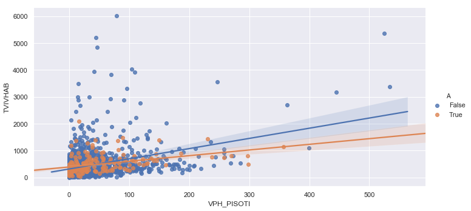

```python
AX=sns.lmplot(x='VPH_PISOTI',y='TVIVHAB',data=df,hue='A',aspect=2)
```

Parece haber una diferencia significativa en este ratio.

Veamos cómo son las distribuciones de nuestra población respecto a sus grados promedio de escolaridad.

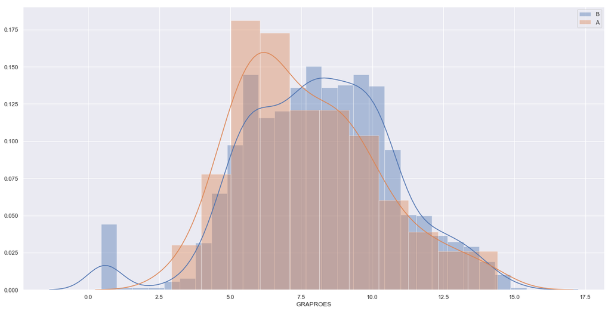

```python
ax=sns.distplot(dfB.GRAPROES,label='B')
ax=sns.distplot(dfA.GRAPROES,label='A',ax=ax)
ax.legend()
```

Parecen ser distribuciones muy distintas, podemos concluir por esta figura y todas las anteriores que nuestra muestra parece tener peores condiciones económicas, esto aunque incurre en mayor riesgo de inversión, también significa mayores retornos esperados. Sin embargo no se puede esperar una industria muy especializada, sino que más bien una que mejor aproveche el entorno. Algo como la maquilación pues la mano de obra debe ser más barata.

En otras palabras, y suponiendo que las condiciones económicas peores significan mayores areas de oportunidad yo haría las siguientes recomendaciones.

- La participación en la economía es peor en nuestra submuestra A.
- La educación es peor en nuestra submuestra A, lo que no soportaría industria tan especializada.
- Parecen tener una distribución demógrafica parecida ambos grupos.
- La calidad de la vivienda es más baja en el grupo A.

Muchos **retos** pero grandes **areas de oportunidad**.

## Pregunta 2

Para nuestro PCA utilizaremos las siguientes variables:

```python
cols=[]
for i,typex in enumerate(df.dtypes):
    if(typex!='object'):
        cols.append(df.columns[i])
print(cols)
```

[output not shown]

Con una cantidad de variables total:

```python
len(cols)
```

```
76
```

Apliquemos **PCA** y veamos la explicación de las primeras 3 variables:

```python
X=df[cols].values
x = StandardScaler().fit_transform(X)
pca = PCA(n_components=3)
principalComponents = pca.fit_transform(x)
df['pca1']=principalComponents[:,0]
df['pca2']=principalComponents[:,1]
df['pca3']=principalComponents[:,2]
cols.append('pca1')
cols.append('pca2')
cols.append('pca3')
pca.explained_variance_
```

```
array([41.58417124, 11.28105276,  6.04032318])
```

Veamos nuestras correlaciones con las variables. Es interesante ver como las variables importantes en algunos componentes dejan de ser las variables importantes en el resto.

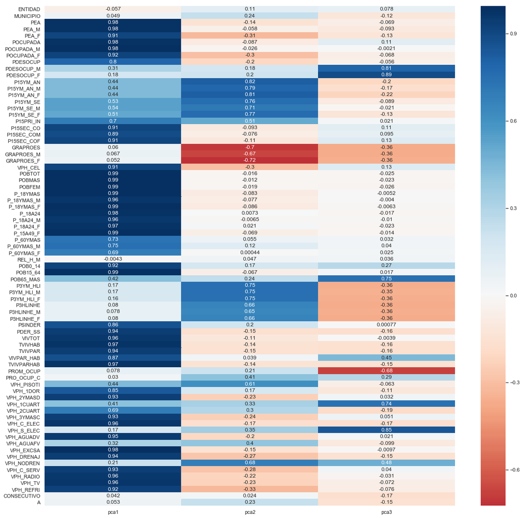

```python
plt.rcParams["figure.figsize"] = (20,20)
corr=df[cols].corr().values
ax=sns.heatmap(corr[:-3,-3:],cmap='RdBu',yticklabels=cols[:-3],xticklabels=cols[-3:],annot=True,center=0)
```

Interpretar estas 76 variables puede ser complicado, sin embargo concentrémonos en las últimas 2 columnas, es fácil ver que nuestra 2da componente está muy relacionada con poblaciones de 15 años analfabetas y sin escolaridad y negativamente correlacionado con el grado promedio de estudios. Es decir nuestra segunda componente engloba mucha de la información de la escolaridad. La tercera componente está muy negativamente correlacionada con el promedio de ocupantes de viviendas particulares ocupadas y positivamente con las viviendas sin electricidad, de un solo cuarto y con la desocupación de hombres y mujeres.

A continuación veamos nuestras 2 primeras componentes:

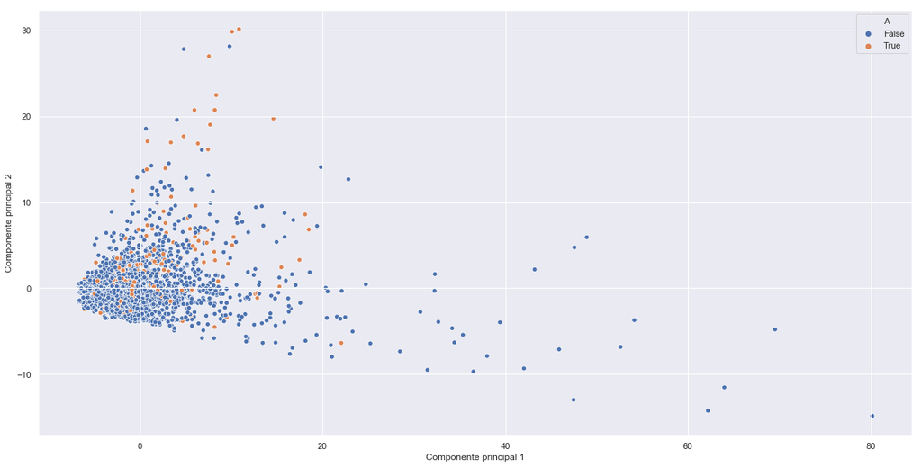

```python
sns.set()
plt.rcParams["figure.figsize"] = (20,10)
fig,ax=plt.subplots()
ax=sns.scatterplot(x=principalComponents[:,0],y=principalComponents[:,1],hue=df.A,zorder=0,ax=ax)
ax.set_xlabel('Componente principal 1')
ax=ax.set_ylabel('Componente principal 2')
```

No parecen separar bien a nuestras muestras sin embargo las segundas 2 componentes parecen ser mucho más explicativas para la región. Veamos estas 2:

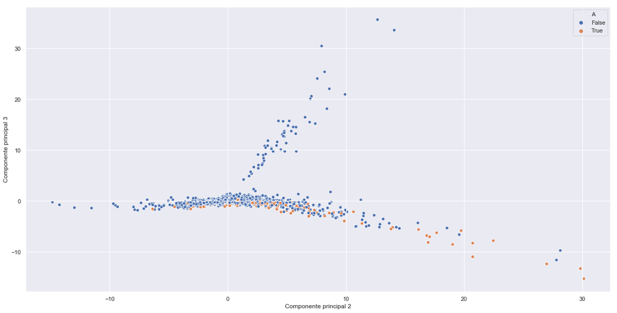

```python
sns.set()
plt.rcParams["figure.figsize"] = (20,10)
fig,ax=plt.subplots()
ax=sns.scatterplot(x=principalComponents[:,1],y=principalComponents[:,2],hue=df.A,zorder=0,ax=ax)
ax.set_xlabel('Componente principal 2')
ax=ax.set_ylabel('Componente principal 3')
```

Es interesante ver como las componentes principales 2 y 3 separan mejor a nuestra muestra. La 2 especificamente capturando la información de escolaridad. Es decir **negativamente** correlacionada con la escolaridad. Y la 3 capturando información de desocupación laboral **positivamente** y ocupación de viviendas **negativamente**.

## Pregunta 3

Por la figura anterior es fácil ver que la proyección en las componentes 2 y 3 podría ser un buen criterio de separación, sin embargo intentemos el **LDA** entrenado con la muestra de **2500** y probado con la base de datos **real**. Veamos su **matriz de confusión**:

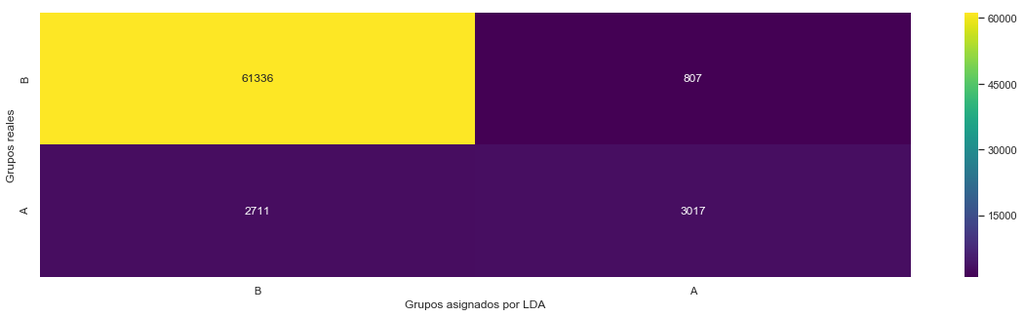

```python
from sklearn.discriminant_analysis import LinearDiscriminantAnalysis
dffull=pd.read_csv('datos-EXAMEN-FINAL-ok.csv',na_values=[' ']).dropna()
dffull['A']=dffull.NOM_ENT.str.contains('CHIAPAS|TABASCO|QUINTANA ROO|CAMPECHE|YUCATAN',regex=True)==True

X_train = df[cols[:-4]]
y = df.A
lda = LinearDiscriminantAnalysis(n_components=2)
lda.fit(X_train, y)
X = dffull[cols[:-4]]
y_pred=lda.predict(X)
y_true=dffull.A
from sklearn.metrics import confusion_matrix
plt.rcParams["figure.figsize"] = (20,5)
cm = confusion_matrix(y_true,y_pred)
ax=sns.heatmap(cm,annot=True,cmap='viridis',fmt='g',yticklabels=['B','A'],xticklabels=['B','A'])
ax.set_ylabel('Grupos reales')
ax=ax.set_xlabel('Grupos asignados por LDA')
```

Que tiene la siguiente **precisión**:

```python
from sklearn.metrics import accuracy_score
accuracy_score(y_true,y_pred)
```

```
0.9481663744456396
```

Es decir una **Precisión** bastante buena.

## Pregunta 4

A continuación se intentará con las siguientes variables por elección con base en los PCA's anteriores:

```python
cols2=['GRAPROES','PROM_OCUP','VPH_PISOTI','PDESOCUP_F','PDESOCUP_M','VPH_S_ELEC','VPH_1CUART','VPH_NODREN','POB65_MAS']
print(cols2)
```

```
['GRAPROES', 'PROM_OCUP', 'VPH_PISOTI', 'PDESOCUP_F', 'PDESOCUP_M', 'VPH_S_ELEC', 'VPH_1CUART', 'VPH_NODREN', 'POB65_MAS']
```

Veamos matriz de confusión y precisión:

```
0.9116559355247454
```

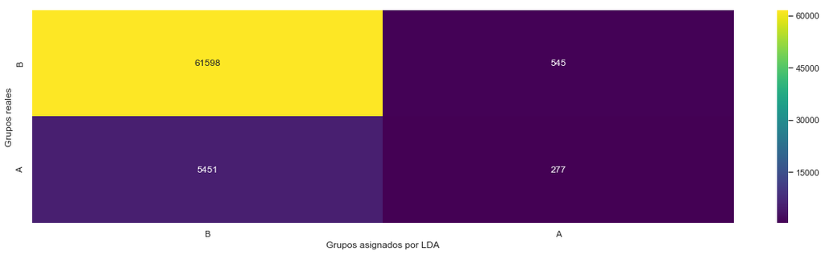

```python
X_train = df[cols2]
y = df.A
lda = LinearDiscriminantAnalysis(n_components=2)
lda.fit(X_train, y)
X = dffull[cols2]
y_pred=lda.predict(X)
y_true=dffull.A
from sklearn.metrics import confusion_matrix
plt.rcParams["figure.figsize"] = (20,5)
cm = confusion_matrix(y_true,y_pred)
ax=sns.heatmap(cm,annot=True,cmap='viridis',fmt='g',yticklabels=['B','A'],xticklabels=['B','A'])
ax.set_ylabel('Grupos reales')
ax=ax.set_xlabel('Grupos asignados por LDA')
from sklearn.metrics import accuracy_score
print(accuracy_score(y_true,y_pred))
```

Si bien vemos que la precisíon es **alta**, esto está dado porque nuestras poblaciones A y B están desbalanceadas. Es decir nuestro grupo B es muy grande, mientras que nuestro grupo A es muy pequeño. Alguna mejor medida que la precisión ayudaría a ponderar mejor el número de falsos positivos y falsos negativos.